# Untitled

Q3:

```r
library(GSVA)
library(GSEABase)
library(limma)
#  GSVA analysis
KEGG_s <- getGmt("c2.cp.kegg.v2022.1.Hs.symbols.gmt")
class(KEGG_s)
```

```
## [1] "GeneSetCollection"
## attr(,"package")
## [1] "GSEABase"
```

```r
param <- gsvaParam(expr = as.matrix(normalizeddata_log),
                   geneSets = KEGG_s,
                   kcdf = "Gaussian")

Gsva_es <- gsva(param)
```

[output not shown]

[output not shown]

[output not shown]

[output not shown]

[output not shown]

[output not shown]

[output not shown]

[output not shown]

[output not shown]

[output not shown]

```r
dim(Gsva_es)
```

```
## [1] 186  10
```

```r
design <- model.matrix(~ Patient + Group, data=sample.info)
fit <- lmFit(Gsva_es, design)
fit_1 <- eBayes(fit)
gsva_kegg_results <- topTable(fit_1, coef="GroupTumour", adjust="BH", n=Inf)

# list top 10 mostly significantly differential expression KEGG pathway
significant_pathways <- rownames(gsva_kegg_results)[gsva_kegg_results$adj.P.Val <= 0.01]
length(significant_pathways)
```

```
## [1] 0
```

```r
if(length(significant_pathways) >= 2){
  significant_pathways_es <- Gsva_es[significant_pathways, ]
  significant_pathways_es[is.na(significant_pathways_es)] <- 0
  heatmap(significant_pathways_es,
          scale="row",
          margins=c(5,15))}

gsva_kegg_results_sorted <- gsva_kegg_results[order(gsva_kegg_results$adj.P.Val), ]
top10 <- head(gsva_kegg_results_sorted, 10)
top10
```

```
##                                                        logFC      AveExpr
## KEGG_DRUG_METABOLISM_CYTOCHROME_P450              -0.5469246  0.019638708
## KEGG_NITROGEN_METABOLISM                          -0.5874675  0.027079033
## KEGG_ASCORBATE_AND_ALDARATE_METABOLISM            -0.5800881  0.068179014
## KEGG_STARCH_AND_SUCROSE_METABOLISM                -0.4880543  0.023440381
## KEGG_HISTIDINE_METABOLISM                         -0.5033017 -0.012288294
## KEGG_ETHER_LIPID_METABOLISM                       -0.4300213  0.020897019
## KEGG_METABOLISM_OF_XENOBIOTICS_BY_CYTOCHROME_P450 -0.4872259  0.031624516
## KEGG_LYSOSOME                                     -0.4447488 -0.001065876
## KEGG_STEROID_HORMONE_BIOSYNTHESIS                 -0.5184088  0.047952127
## KEGG_GLYCOSPHINGOLIPID_BIOSYNTHESIS_GLOBO_SERIES  -0.4759416 -0.011791047
##                                                           t      P.Value
## KEGG_DRUG_METABOLISM_CYTOCHROME_P450              -5.385539 0.0002850735
## KEGG_NITROGEN_METABOLISM                          -5.263280 0.0003404135
## KEGG_ASCORBATE_AND_ALDARATE_METABOLISM            -5.236213 0.0003541527
## KEGG_STARCH_AND_SUCROSE_METABOLISM                -4.782958 0.0006977582
## KEGG_HISTIDINE_METABOLISM                         -4.618039 0.0008995539
## KEGG_ETHER_LIPID_METABOLISM                       -4.596713 0.0009298543
## KEGG_METABOLISM_OF_XENOBIOTICS_BY_CYTOCHROME_P450 -4.434184 0.0011994390
## KEGG_LYSOSOME                                     -4.332640 0.0014088419
## KEGG_STEROID_HORMONE_BIOSYNTHESIS                 -4.306200 0.0014694630
## KEGG_GLYCOSPHINGOLIPID_BIOSYNTHESIS_GLOBO_SERIES  -4.256786 0.0015902446
##                                                    adj.P.Val          B
## KEGG_DRUG_METABOLISM_CYTOCHROME_P450              0.02195747  0.6939958
## KEGG_NITROGEN_METABOLISM                          0.02195747  0.5378852
## KEGG_ASCORBATE_AND_ALDARATE_METABOLISM            0.02195747  0.5029695
## KEGG_STARCH_AND_SUCROSE_METABOLISM                0.02689454 -0.1006452
## KEGG_HISTIDINE_METABOLISM                         0.02689454 -0.3290395
## KEGG_ETHER_LIPID_METABOLISM                       0.02689454 -0.3589075
## KEGG_METABOLISM_OF_XENOBIOTICS_BY_CYTOCHROME_P450 0.02689454 -0.5890161
## KEGG_LYSOSOME                                     0.02689454 -0.7349617
## KEGG_STEROID_HORMONE_BIOSYNTHESIS                 0.02689454 -0.7732311
## KEGG_GLYCOSPHINGOLIPID_BIOSYNTHESIS_GLOBO_SERIES  0.02689454 -0.8450484
```

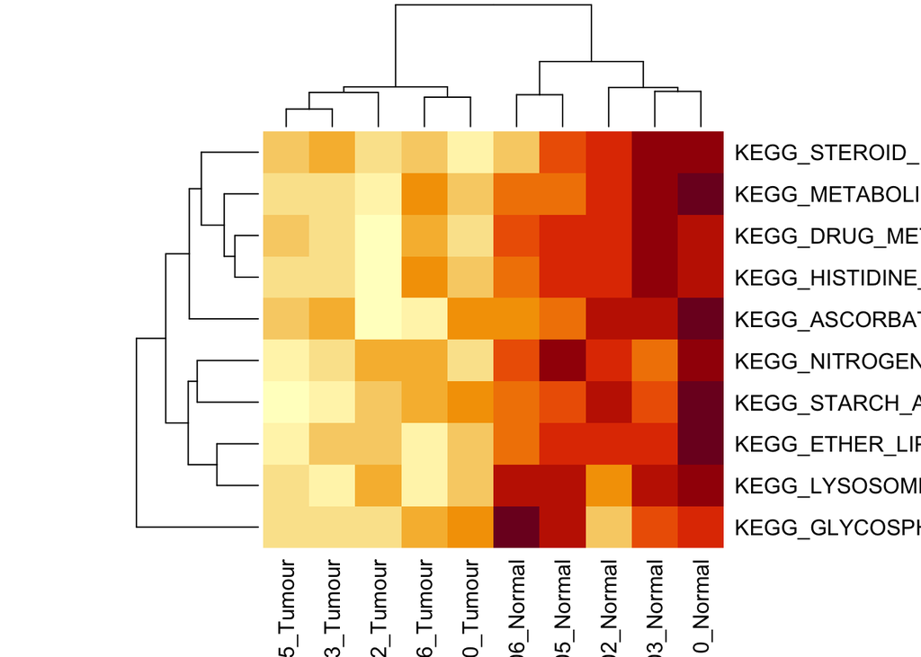

```r
# heatmap for mostly significantly differentially regulated KEGG
top10_list <- rownames(gsva_kegg_results)[1:10]
top10_es <- Gsva_es[top10_list, ]
top10_es[is.na(top10_es)] <- 0
heatmap(top10_es, scale="row", margins=c(5,3))
```

While no pathways met our initial, strict significance p-adj ≤ 0.01, we examined the top 10 ranked pathways to identify potential trends. These were focused on metabolic processes(carbohydrate, lipid, and steroid hormone metabolism).The majority displayed negative log fold change values, which means a general reduction in metabolic enrichment in the tumor samples. This distinction between the two groups was further confirmed by the heatmap, highlighting the difference pathway enrichment patterns between tumour and normal samples